# CELL’ECTION

Marianne, Emilie et Lélia

2018-03-29

# Framework Laravel

Laravel est un framework d’application web. Il permet facilement d’implémenter des fonctionnalités courantes utilisées dans des projets comme:

- un sytème de routage,
- un créateur de requête SQL et un ORM performants,
- un moteur de template,
- un système d’authentification pour les connexions,
- un système de migration pour les bases de données,
- un système d’envoi d’emails,
- un système d’autorisations,
- une gestion de session.

Laravel est aussi beaucoup documenté, sur son site officiel : https://laravel.com/docs/5.5, mais aussi d’autres nombreuses sources.

Lors d’une création d’un projet, Laravel génère une structure contenant divers fichiers. Afin de permettre de comprendre le code que nous avons développés pendant le projet, nous vous précisons les fichiers que nous avons créés ou modifiés.

## Installation de Laravel

Avant de commencer, assurez-vous d’avoir installer composer: https://getcomposer.org/

Lancez mysql et créez la base de données:

```bash
mysql -uroot [-p] # -p si vous souhaitez créer un mot de passe pour la base de données
CREATE DATABASE cellection_database
```

Dans le fichier .env du projet Cell_ection, modifier tel que:

```bash
DB_CONNECTION=mysql
DB_HOST=127.0.0.1
DB_PORT=3306
DB_DATABASE=cellection_database
DB_USERNAME=root
DB_PASSWORD= #facultatif
```

Afin de visualiser la base de données assurez-vous d’avoir un visualisateur de base de données : Nous vous conseillons: pour Linux DBeaver et pour Osx SequelPro.

Dès lors, il existe 2 solutions pour créer et peupler les tables de la base de données:

### Solution 1:

Avec cette solution, le peuplement dure environs 2h.

```bash
composer dump-autoload
php artisan migrate
php artisan db:seed
```

### Solution 2:

Avec cette solution, récupérer préalablement, le fichier cellection.sql sur le git. Il contient la base de donnée déjà peuplée.

Lancer le visualiseur de base de données:

- DBeaver: Sélectionner la base de donnée dans la liste. Faire un clique-droit > Outils > Execute script. Et sélection le fichier cellection.sql.

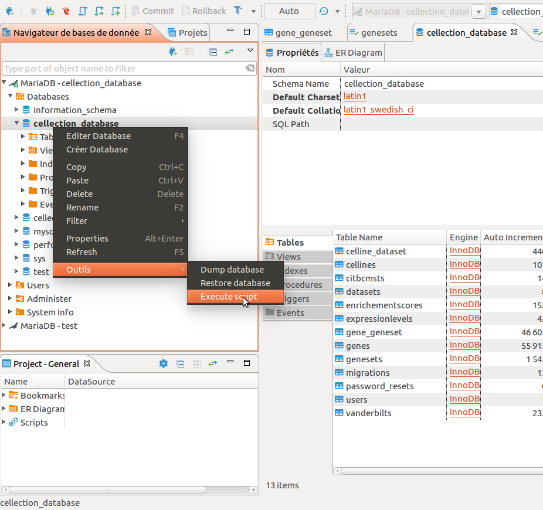

- SequelPro: Fichier > Importer > cellection.sql.

[figure not shown]

Maintenant la base de données est peuplée, vous pouvez le vérifier dans le visualisateur.

Lancer depuis le terminal dans le fichier Cell_ection:

`bash php artisan serve`

Ouvrez le lien dans un navigateur et vous pourrez alors accéder au site en local.